# Data605 Final

Gabe Abreu

12/19/2020

## Data 605 Final

# Problem 1.

Using R, generate a random variable X that has 10,000 random uniform numbers from 1 to N, where N can be any number of your choosing greater than or equal to 6. Then generate a random variable Y that has 10,000 random normal numbers with a mean of mu =sigma=(N+1)/2

```r
#set.seed function ensures results are reproducible
set.seed(100)

#create variables
N <- 8
mu <- (N + 1)/2
devi <- mu
```

Probability. Calculate as a minimum the below probabilities a through c. Assume the small letter “x” is estimated as the median of the X variable, and the small letter “y” is estimated as the 1st quartile of the Y variable. Interpret the meaning of all probabilities.

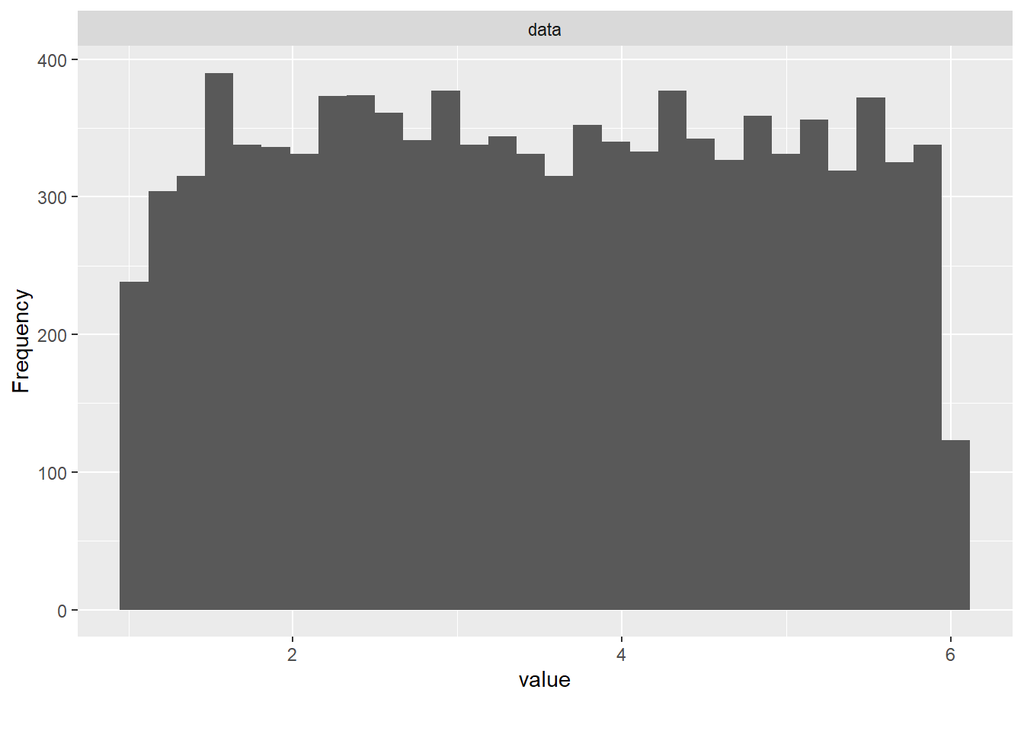

```r
X <- runif(10000, min=1, max=6)
Y <- rnorm(10000, mean= mu, sd=devi)


#Graph histograms to show distribution
plot_histogram(X)
```

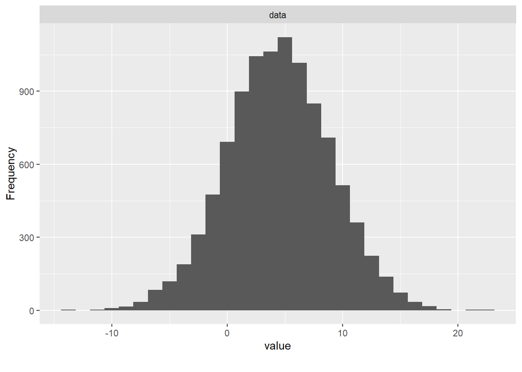

```r
plot_histogram(Y)
```

```r
#create little x and y

# Assume the small letter "x" is estimated as the median of the X variable
x <- median(X)

# small letter "y" is estimated as the 1st quartile of the Y variable
y <- quantile(Y, 0.25)
```

1a.P(X>x | X>y) Reference: https://stats.stackexchange.com/questions/391756/using-conditional-probability-to-calculate-sentiment-score-probability

```r
#Means conditional probability  -> P(X>x and X>y)/P(X>y) --> P(AB)/P(B)
#Find the determine cases where B (...or the second case in our situation) is true and given B where A is also true.
sum(X>x & X>y) / sum(X>y)
```

```
## [1] 0.5444251
```

1b.P(X>x, Y>y)

```r
#Both are independent events
#Formula used P( A and B) = P(A)P(B)//Finding the intersection of A and B, both occur simulateneously
#Length of both X and Y are 10000

sum(X>x & Y>y)/length(X)
```

```
## [1] 0.3755
```

1c.P(X<x | X>y)

```r
sum(X<x & X>y)/sum(X>y)
```

```
## [1] 0.4555749
```

2. Investigate whether P(X>x and Y>y)=P(X>x)P(Y>y) by building a table and evaluating the marginal and joint probabilities

```r
#Start the creation of the table
X_grt_x_Y_grt_y <- sum(X>x & Y>y)


X_lsr_x_Y_lsr_y <- sum(X<x & Y<y)


X_grt_x_Y_lsr_y <- sum(X>x & Y<y)


X_lsr_x_Y_grt_y <- sum(X<x & Y>y)


table <- matrix(c(X_grt_x_Y_grt_y, X_grt_x_Y_lsr_y, X_lsr_x_Y_grt_y, X_lsr_x_Y_lsr_y), nrow=2, ncol=2)
colnames(table) <- c('X > x', ' X < x')
rownames(table) <- c('Y > y', 'Y < y')
print(table)
```

```
##       X > x  X < x
## Y > y  3755   3745
## Y < y  1245   1255
```

```r
#P(X>x and Y>y)
a <- 3755 / 10000

#P(X>x)P(Y>y)
b <- sum(X>x & Y>y)/10000

Are_Equal <- a == b
Are_Equal
```

```
## [1] TRUE
```

3. Check to see if independence holds by using Fisher’s Exact Test and the Chi Square Test. What is the difference between the two? Which is most appropriate?

```r
#Run Fisher test
fisher.test(table)
```

```
##
##  Fisher's Exact Test for Count Data
##
## data:  table
## p-value = 0.8354
## alternative hypothesis: true odds ratio is not equal to 1
## 95 percent confidence interval:
##  0.9222661 1.1076494
## sample estimates:
## odds ratio
##   1.010724
```

```r
#Chi Square Test
chisq.test(table)
```

```
##
##  Pearson's Chi-squared test with Yates' continuity correction
##
## data:  table
## X-squared = 0.0432, df = 1, p-value = 0.8353
```

The p-values for both tests are very large (significantly above the 0.05), therefore we fail to reject the null-hypothesis. These events are indeed indepdent.

The chi-squared test is an appropriate approximation when the sample is large, while the Fisher exact test runs a precise procedure for small-sized samples. (reference: https://www.ncbi.nlm.nih.gov/pmc/articles/PMC5426219/#:~:text=The%20chi%2Dsquared%20test%20applies,especially%20for%20small%2Dsized%20samples.) Since the case is large, I would say the chi-test is most appropriate.

# Problem 2.

You are to register for Kaggle.com (free) and compete in the House Prices: Advanced Regression Techniques competition. https://www.kaggle.com/c/house-prices-advanced-regression-techniques . I want you to do the following.

Preliminary

```r
#Load Data

#Train
train <- read.csv("train.csv", header = TRUE, sep=',')

#Test
test <- read.csv("test.csv", header = TRUE, sep=',')
```

2a.

Descriptive and Inferential Statistics

Provide univariate descriptive statistics and appropriate plots for the training data set. Provide a scatterplot matrix for at least two of the independent variables and the dependent variable. Derive a correlation matrix for any three quantitative variables in the dataset. Test the hypotheses that the correlations between each pairwise set of variables is 0 and provide an 80% confidence interval. Discuss the meaning of your analysis. Would you be worried about familywise error? Why or why not?

Descriptive Statistics

```r
##View the first five rows of the dataset
head(train)
```

```
##   Id MSSubClass MSZoning LotFrontage LotArea Street Alley LotShape LandContour
## 1  1         60       RL          65    8450   Pave  <NA>      Reg         Lvl
## 2  2         20       RL          80    9600   Pave  <NA>      Reg         Lvl
## 3  3         60       RL          68   11250   Pave  <NA>      IR1         Lvl
## 4  4         70       RL          60    9550   Pave  <NA>      IR1         Lvl
## 5  5         60       RL          84   14260   Pave  <NA>      IR1         Lvl
## 6  6         50       RL          85   14115   Pave  <NA>      IR1         Lvl
##   Utilities LotConfig LandSlope Neighborhood Condition1 Condition2 BldgType
## 1    AllPub    Inside       Gtl      CollgCr       Norm       Norm     1Fam
## 2    AllPub       FR2       Gtl      Veenker      Feedr       Norm     1Fam
## 3    AllPub    Inside       Gtl      CollgCr       Norm       Norm     1Fam
## 4    AllPub    Corner       Gtl      Crawfor       Norm       Norm     1Fam
## 5    AllPub       FR2       Gtl      NoRidge       Norm       Norm     1Fam
## 6    AllPub    Inside       Gtl      Mitchel       Norm       Norm     1Fam
##   HouseStyle OverallQual OverallCond YearBuilt YearRemodAdd RoofStyle RoofMatl
```

[output cut: 69 more lines]

```r
#Find out total rows and columns
dim(train)
```

```
## [1] 1460   81
```

```r
#Lets view the data types of the variables
glimpse(train)
```

```
## Observations: 1,460
## Variables: 81
## $ Id            <int> 1, 2, 3, 4, 5, 6, 7, 8, 9, 10, 11, 12, 13, 14, 15, 16...
## $ MSSubClass    <int> 60, 20, 60, 70, 60, 50, 20, 60, 50, 190, 20, 60, 20, ...
## $ MSZoning      <fct> RL, RL, RL, RL, RL, RL, RL, RL, RM, RL, RL, RL, RL, R...
## $ LotFrontage   <int> 65, 80, 68, 60, 84, 85, 75, NA, 51, 50, 70, 85, NA, 9...
## $ LotArea       <int> 8450, 9600, 11250, 9550, 14260, 14115, 10084, 10382, ...
## $ Street        <fct> Pave, Pave, Pave, Pave, Pave, Pave, Pave, Pave, Pave,...
## $ Alley         <fct> NA, NA, NA, NA, NA, NA, NA, NA, NA, NA, NA, NA, NA, N...
## $ LotShape      <fct> Reg, Reg, IR1, IR1, IR1, IR1, Reg, IR1, Reg, Reg, Reg...
## $ LandContour   <fct> Lvl, Lvl, Lvl, Lvl, Lvl, Lvl, Lvl, Lvl, Lvl, Lvl, Lvl...
## $ Utilities     <fct> AllPub, AllPub, AllPub, AllPub, AllPub, AllPub, AllPu...
## $ LotConfig     <fct> Inside, FR2, Inside, Corner, FR2, Inside, Inside, Cor...
## $ LandSlope     <fct> Gtl, Gtl, Gtl, Gtl, Gtl, Gtl, Gtl, Gtl, Gtl, Gtl, Gtl...
## $ Neighborhood  <fct> CollgCr, Veenker, CollgCr, Crawfor, NoRidge, Mitchel,...
```

[output cut: 68 more lines]

```r
#Overall statistics
summary(train)
```

```
##        Id           MSSubClass       MSZoning     LotFrontage
##  Min.   :   1.0   Min.   : 20.0   C (all):  10   Min.   : 21.00
##  1st Qu.: 365.8   1st Qu.: 20.0   FV     :  65   1st Qu.: 59.00
##  Median : 730.5   Median : 50.0   RH     :  16   Median : 69.00
##  Mean   : 730.5   Mean   : 56.9   RL     :1151   Mean   : 70.05
##  3rd Qu.:1095.2   3rd Qu.: 70.0   RM     : 218   3rd Qu.: 80.00
##  Max.   :1460.0   Max.   :190.0                  Max.   :313.00
##                                                  NA's   :259
##     LotArea        Street      Alley      LotShape  LandContour  Utilities
##  Min.   :  1300   Grvl:   6   Grvl:  50   IR1:484   Bnk:  63    AllPub:1459
##  1st Qu.:  7554   Pave:1454   Pave:  41   IR2: 41   HLS:  50    NoSeWa:   1
##  Median :  9478               NA's:1369   IR3: 10   Low:  36
##  Mean   : 10517                           Reg:925   Lvl:1311
##  3rd Qu.: 11602
##  Max.   :215245
##
##    LotConfig    LandSlope   Neighborhood   Condition1     Condition2
##  Corner : 263   Gtl:1382   NAmes  :225   Norm   :1260   Norm   :1445
##  CulDSac:  94   Mod:  65   CollgCr:150   Feedr  :  81   Feedr  :   6
##  FR2    :  47   Sev:  13   OldTown:113   Artery :  48   Artery :   2
##  FR3    :   4              Edwards:100   RRAn   :  26   PosN   :   2
##  Inside :1052              Somerst: 86   PosN   :  19   RRNn   :   2
##                            Gilbert: 79   RRAe   :  11   PosA   :   1
##                            (Other):707   (Other):  15   (Other):   2
##    BldgType      HouseStyle   OverallQual      OverallCond      YearBuilt
##  1Fam  :1220   1Story :726   Min.   : 1.000   Min.   :1.000   Min.   :1872
##  2fmCon:  31   2Story :445   1st Qu.: 5.000   1st Qu.:5.000   1st Qu.:1954
##  Duplex:  52   1.5Fin :154   Median : 6.000   Median :5.000   Median :1973
##  Twnhs :  43   SLvl   : 65   Mean   : 6.099   Mean   :5.575   Mean   :1971
##  TwnhsE: 114   SFoyer : 37   3rd Qu.: 7.000   3rd Qu.:6.000   3rd Qu.:2000
##                1.5Unf : 14   Max.   :10.000   Max.   :9.000   Max.   :2010
##                (Other): 19
##   YearRemodAdd    RoofStyle       RoofMatl     Exterior1st   Exterior2nd
##  Min.   :1950   Flat   :  13   CompShg:1434   VinylSd:515   VinylSd:504
##  1st Qu.:1967   Gable  :1141   Tar&Grv:  11   HdBoard:222   MetalSd:214
##  Median :1994   Gambrel:  11   WdShngl:   6   MetalSd:220   HdBoard:207
##  Mean   :1985   Hip    : 286   WdShake:   5   Wd Sdng:206   Wd Sdng:197
##  3rd Qu.:2004   Mansard:   7   ClyTile:   1   Plywood:108   Plywood:142
##  Max.   :2010   Shed   :   2   Membran:   1   CemntBd: 61   CmentBd: 60
##                                (Other):   2   (Other):128   (Other):136
```

[output cut: 81 more lines]

```
##  Min.   :    0.00   Min.   : 1.000   Min.   :2006   WD     :1267
##  1st Qu.:    0.00   1st Qu.: 5.000   1st Qu.:2007   New    : 122
##  Median :    0.00   Median : 6.000   Median :2008   COD    :  43
##  Mean   :   43.49   Mean   : 6.322   Mean   :2008   ConLD  :   9
##  3rd Qu.:    0.00   3rd Qu.: 8.000   3rd Qu.:2009   ConLI  :   5
##  Max.   :15500.00   Max.   :12.000   Max.   :2010   ConLw  :   5
##                                                     (Other):   9
##  SaleCondition    SalePrice
##  Abnorml: 101   Min.   : 34900
##  AdjLand:   4   1st Qu.:129975
##  Alloca :  12   Median :163000
##  Family :  20   Mean   :180921
##  Normal :1198   3rd Qu.:214000
##  Partial: 125   Max.   :755000
##
```

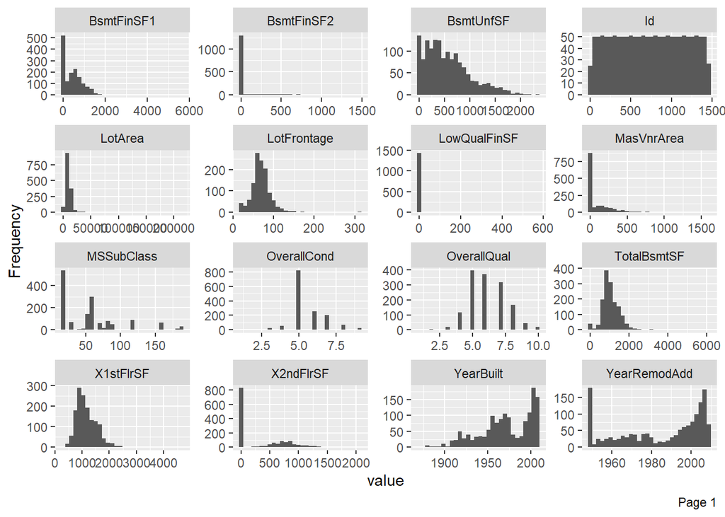

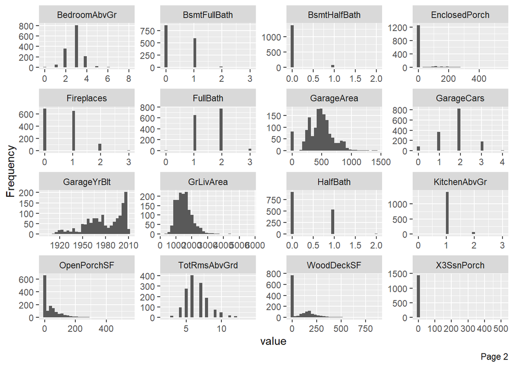

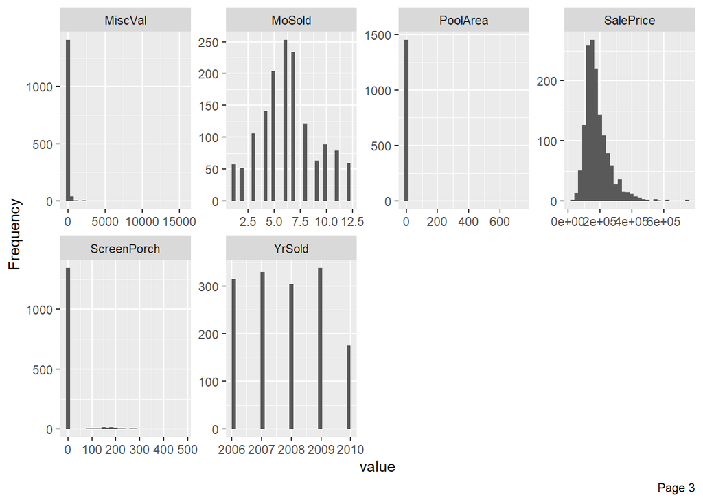

```r
#View how the variables are skewed
plot_histogram(train)
```

Provide a scatterplot matrix for at least two of the independent variables and the dependent variable. The 2 independent variables: X1stFlrSF : First floor square feet GrLivArea: Above ground living area

Dependent variable: SalePrice: sale price of the house

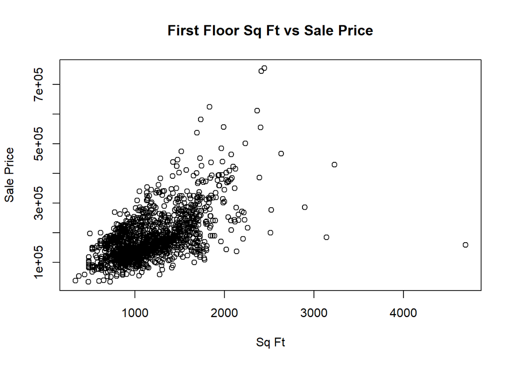

```r
plot(train$X1stFlrSF, train$SalePrice,
     main = "First Floor Sq Ft vs Sale Price",
     xlab = "Sq Ft",
     ylab = 'Sale Price')
```

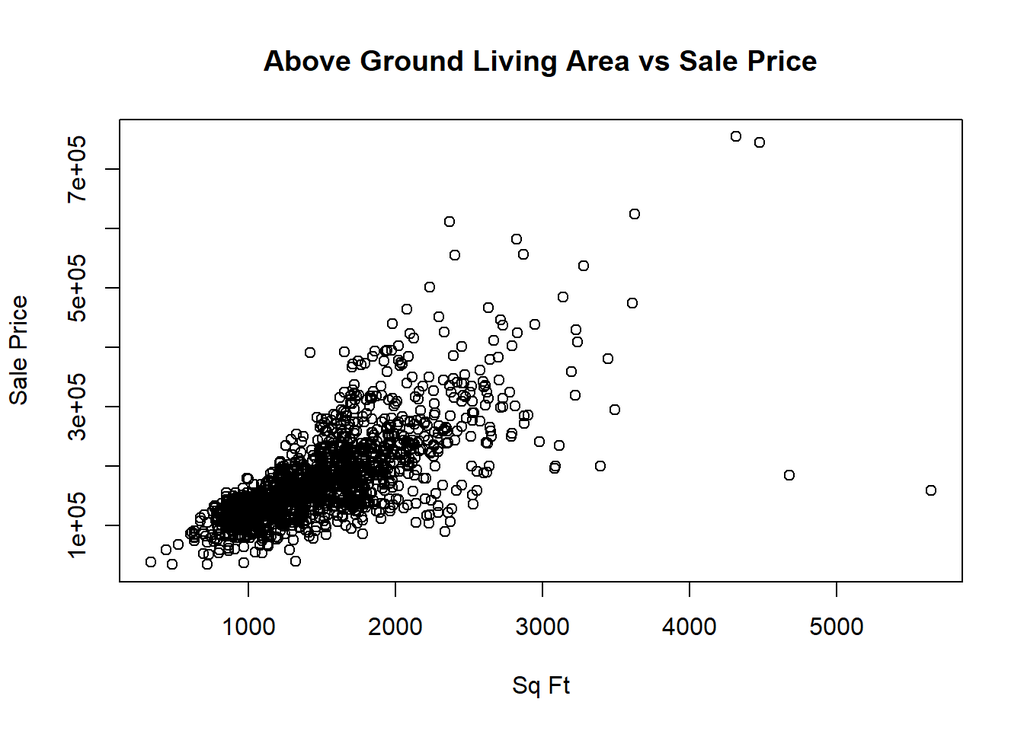

```r
plot(train$GrLivArea, train$SalePrice,
     main = "Above Ground Living Area vs Sale Price",
     xlab = "Sq Ft",
     ylab = 'Sale Price')
```

Derive a correlation matrix for any three quantitative variables in the dataset

```r
corr_matrix <- cor(train[c("OverallQual", "GrLivArea", "SalePrice")])
corr_matrix
```

```
##             OverallQual GrLivArea SalePrice
## OverallQual   1.0000000 0.5930074 0.7909816
## GrLivArea     0.5930074 1.0000000 0.7086245
## SalePrice     0.7909816 0.7086245 1.0000000
```

Test the hypotheses that the correlations between each pairwise set of variables is 0 and provide an 80% confidence interval

```r
cor.test(train$OverallQual, train$SalePrice, conf.level = 0.8)
```

```
##
##  Pearson's product-moment correlation
##
## data:  train$OverallQual and train$SalePrice
## t = 49.364, df = 1458, p-value < 2.2e-16
## alternative hypothesis: true correlation is not equal to 0
## 80 percent confidence interval:
##  0.7780752 0.8032204
## sample estimates:
##       cor
## 0.7909816
```

```r
cor.test(train$OverallQual, train$GrLivArea, conf.level = 0.8)
```

```
##
##  Pearson's product-moment correlation
##
## data:  train$OverallQual and train$GrLivArea
## t = 28.121, df = 1458, p-value < 2.2e-16
## alternative hypothesis: true correlation is not equal to 0
## 80 percent confidence interval:
##  0.5708061 0.6143422
## sample estimates:
##       cor
## 0.5930074
```

```r
cor.test(train$GrLivArea, train$SalePrice, conf.level = 0.8)
```

```
##
##  Pearson's product-moment correlation
##
## data:  train$GrLivArea and train$SalePrice
## t = 38.348, df = 1458, p-value < 2.2e-16
## alternative hypothesis: true correlation is not equal to 0
## 80 percent confidence interval:
##  0.6915087 0.7249450
## sample estimates:
##       cor
## 0.7086245
```

The three tests show a p-value that is much lower than the significant p-valuce of 0.05, meaning the null hypothesis can be rejected and the true correlation is not 0 for the 3 chosen variables.

2b. Linear Algebra and Correlation

Linear Algebra and Correlation. Invert your correlation matrix from above. (This is known as the precision matrix and contains variance inflation factors on the diagonal.) Multiply the correlation matrix by the precision matrix, and then multiply the precision matrix by the correlation matrix. Conduct LU decomposition on the matrix

```r
#correlation matrix
corr_matrix
```

```
##             OverallQual GrLivArea SalePrice
## OverallQual   1.0000000 0.5930074 0.7909816
## GrLivArea     0.5930074 1.0000000 0.7086245
## SalePrice     0.7909816 0.7086245 1.0000000
```

```r
#invert the matrix
inverted_corr_matrix = solve(corr_matrix)
inverted_corr_matrix
```

```
##             OverallQual  GrLivArea SalePrice
## OverallQual   2.6865350 -0.1753704 -2.000728
## GrLivArea    -0.1753704  2.0200794 -1.292763
## SalePrice    -2.0007280 -1.2927630  3.498623
```

```r
#multiply correlation matrix by precision matrix
corr_matrix %*% inverted_corr_matrix
```

```
##             OverallQual GrLivArea SalePrice
## OverallQual           1         0         0
## GrLivArea             0         1         0
## SalePrice             0         0         1
```

```r
#multiply the inverted matrix by the original correlation matrix
inverted_corr_matrix %*% corr_matrix
```

```
##              OverallQual     GrLivArea     SalePrice
## OverallQual 1.000000e+00 -4.440892e-16 -8.881784e-16
## GrLivArea   0.000000e+00  1.000000e+00  0.000000e+00
## SalePrice   4.440892e-16  0.000000e+00  1.000000e+00
```

Conduct LU decomposition on the matrix

```r
library(Matrix)
LU <- lu(corr_matrix)

lower <- expand(LU)$L
lower
```

```
## 3 x 3 Matrix of class "dtrMatrix" (unitriangular)
##      [,1]      [,2]      [,3]
## [1,] 1.0000000         .         .
## [2,] 0.5930074 1.0000000         .
## [3,] 0.7909816 0.3695063 1.0000000
```

```r
upper <- expand(LU)$U
upper
```

```
## 3 x 3 Matrix of class "dtrMatrix"
##      [,1]      [,2]      [,3]
## [1,] 1.0000000 0.5930074 0.7909816
## [2,]         . 0.6483422 0.2395665
## [3,]         .         . 0.2858268
```

```r
lower %*% upper
```

```
## 3 x 3 Matrix of class "dgeMatrix"
##           [,1]      [,2]      [,3]
## [1,] 1.0000000 0.5930074 0.7909816
## [2,] 0.5930074 1.0000000 0.7086245
## [3,] 0.7909816 0.7086245 1.0000000
```

2c. Calculus-Based Probability & Statistics

Calculus-Based Probability & Statistics. Many times, it makes sense to fit a closed form distribution to data. Select a variable in the Kaggle.com training dataset that is skewed to the right, shift it so that the minimum value is absolutely above zero if necessary. Then load the MASS package and run fitdistr to fit an exponential probability density function. (See https://stat.ethz.ch/R-manual/R-devel/library/MASS/html/fitdistr.html ). Find the optimal value of lambda for this distribution, and then take 1000 samples from this exponential distribution using this value (e.g., rexp(1000, lambda). Plot a histogram and compare it with a histogram of your original variable. Using the exponential pdf, find the 5th and 95th percentiles using the cumulative distribution function (CDF). Also generate a 95% confidence interval from the empirical data, assuming normality. Finally, provide the empirical 5th percentile and 95th percentile of the data. Discuss.